# Exploratory Data Analysis. Lab 6: Работа с датами. Пакет lubridate. Агрегация данных

Для начала загрузим базу, с которой будем работать. В базе содержатся информация о сообщений очевидцев НЛО.

Файл достаточно большой, поэтому используем пакет для быстрой загрузки таблиц данных `readr`

```r
library(readr)
ufo = read_tsv("~/shared/minor2_2016/lab06-lubridate/ufo_awesome.tsv", col_names=F)
# naming columns
colnames(ufo) = c("Sighted", "Reported", "Location", "Shape", "Duration", "Description")
```

Посмотрим на данные

```r
head(ufo)
```

```
## # A tibble: 6 x 6
##    Sighted Reported             Location Shape Duration
##      <int>    <int>                <chr> <chr>    <chr>
## 1 19951009 19951009        Iowa City, IA  <NA>     <NA>
## 2 19951010 19951011        Milwaukee, WI  <NA>   2 min.
## 3 19950101 19950103          Shelton, WA  <NA>     <NA>
## 4 19950510 19950510         Columbia, MO  <NA>   2 min.
## 5 19950611 19950614          Seattle, WA  <NA>     <NA>
## 6 19951025 19951024 Brunswick County, ND  <NA>  30 min.
## # ... with 1 more variables: Description <chr>
```

```r
tail(ufo)
```

```
## # A tibble: 6 x 6
##    Sighted Reported            Location    Shape          Duration
##      <int>    <int>               <chr>    <chr>             <chr>
## 1 20100828 20100828     Los Angeles, CA     disk        40 seconds
## 2 20090424 20100820        Hartwell, GA     oval            10 min
## 3 20100821 20100826 Franklin Square, NY fireball        20 minutes
## 4 20100827 20100827        Brighton, CO   circle    at lest 45 min
## 5 20100818 20100821 Dryden (Canada), ON    other 5 Min. maybe more
## 6 20050502 20100824       Fort Knox, KY triangle        15 seconds
## # ... with 1 more variables: Description <chr>
```

- Как вы думаете, что означают первые две колонки?
- Как мы можем посчитать разницу между этими значениями?

# Работа с датами

Для удобной работы с датами есть пакет `lubridate`. Загрузим его

```r
library(lubridate)
```

- В каком порядке расположена информация о дате (день, месяц, год)?

```r
ufo$Sighted = ymd(ufo$Sighted)
ufo$Reported = ymd(ufo$Reported)
```

Рассмотрим еще примеры

```r
date1 = "18-10-2016"
date2 = "10/30/2016"
date3 = "23/3/2016 15:20"
date4 = today()
```

Сначала посмотрим, что же такое `date4`

```r
date4
```

```
## [1] "2016-11-01"
```

```r
class(date4)
```

```
## [1] "Date"
```

Теперь посмотрим на остальные элементы

```r
class(date1)
```

```
## [1] "character"
```

```r
class(date2)
```

```
## [1] "character"
```

```r
class(date3)
```

```
## [1] "character"
```

```r
# date2 - date1
```

Для удобной работы приведем остальные строки к единому формату даты

```r
#date1 = "18-10-2016"
date1 = dmy(date1)
#date2 = "10/30/2016"
date2 = mdy(date2)
#date3 = "23/3/2016 15:20"
date3 = dmy_hm(date3)

class(date1)
```

```
## [1] "Date"
```

```r
class(date2)
```

```
## [1] "Date"
```

```r
class(date3)
```

```
## [1] "POSIXct" "POSIXt"
```

```r
date1
```

```
## [1] "2016-10-18"
```

```r
date2
```

```
## [1] "2016-10-30"
```

```r
date3
```

```
## [1] "2016-03-23 15:20:00 UTC"
```

Из дат в таком формате легко извлекать отдельные части:

```r
year(date1)
```

```
## [1] 2016
```

```r
month(date2)
```

```
## [1] 10
```

```r
month(date2, label = TRUE)
```

```
## [1] Oct
## 12 Levels: Jan < Feb < Mar < Apr < May < Jun < Jul < Aug < Sep < ... < Dec
```

```r
wday(date2)
```

```
## [1] 1
```

```r
wday(date2, label = TRUE)
```

```
## [1] Sun
## Levels: Sun < Mon < Tues < Wed < Thurs < Fri < Sat
```

```r
yday(date3)
```

```
## [1] 83
```

```r
minute(date3)
```

```
## [1] 20
```

Или присваивать им новые значения

```r
second(date3) = 45
date3
```

```
## [1] "2016-03-23 15:20:45 UTC"
```

Когда мы работаем со временем, нам иногда важно учитывать часовой пояс (time zone). По умолчанию используется UTC - Universal Time Coordinate (нулевой меридиан). Указать часовой пояс можно во время преобразования строки в дату `date3 = dmy_hm(date3, tz = "Europe/Moscow")` или уже для преобразованного значения

```r
date3 = force_tz(date3, tzone = "Europe/Moscow")
date3
```

```
## [1] "2016-03-23 15:20:45 MSK"
```

Подробнее о часовых поясах в R можно почитать в справке `?timezones`, `?OlsonNames`, а обозначения найти, например, в [Википедии](https://en.wikipedia.org/wiki/List_of_time_zone_abbreviations).

Кроме того, мы всегда можем посмотреть, какое время будет соответствовать исследуемому в другом часовом поясе, например, для Pacific Daylight Time (North America)

```r
with_tz(date3, tzone = "US/Pacific")
```

```
## [1] "2016-03-23 05:20:45 PDT"
```

### Арифметика с датами и временные интервалы

Одним из важных свойств пакета `lubridate` является возможность осуществлять арифметические операции с датами. При этом мы можем выражать временные данные в разных форматах (месяцы, годы, секунды, минуты…)

```r
date1 - years(2)
```

```
## [1] "2014-10-18"
```

```r
difference = date2 - date1
difference
```

```
## Time difference of 12 days
```

```r
difference/ddays(1)
```

```
## [1] 12
```

```r
difference/dweeks(1)
```

```
## [1] 1.714286
```

```r
difference/dhours(1)
```

```
## [1] 288
```

Больше про функции lubridate: https://cran.r-project.org/web/packages/lubridate/vignettes/lubridate.html

Вернемся к НЛО. Теперь можем посчитать разницу между датой наблюдения и сообщения

```r
library(dplyr)
ufo = mutate(ufo, Difference = (Reported - Sighted)/ddays(1))
```

У нас есть значения, у которых разница отрицательна. Почему так может быть?

Удалим их из данных

```r
ufo = filter(ufo, Difference >= 0)
```

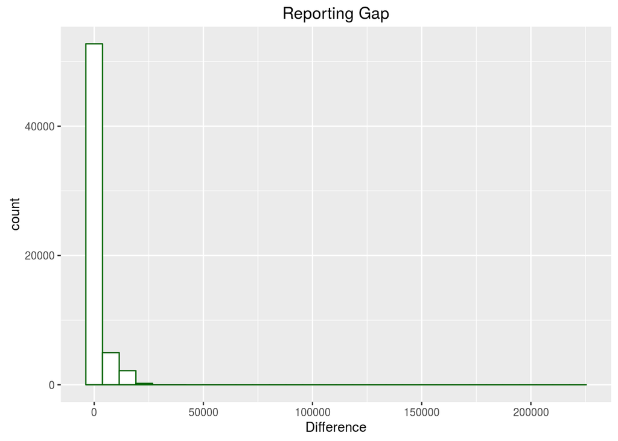

```r
library(ggplot2)
ggplot() +
  geom_histogram(data = ufo, aes(x = Difference),
                colour = "darkgreen", fill="white") +
  ggtitle("Reporting Gap")
```

Большая часть значений близка к 0. Посмотрим на возможные значения

```r
summary(ufo$Difference)
```

```
##    Min. 1st Qu.  Median    Mean 3rd Qu.    Max.
##       0       0       3    1410     213  221500
```

Рассмотрим только значения, попавшие между 1 и 3 квартилем

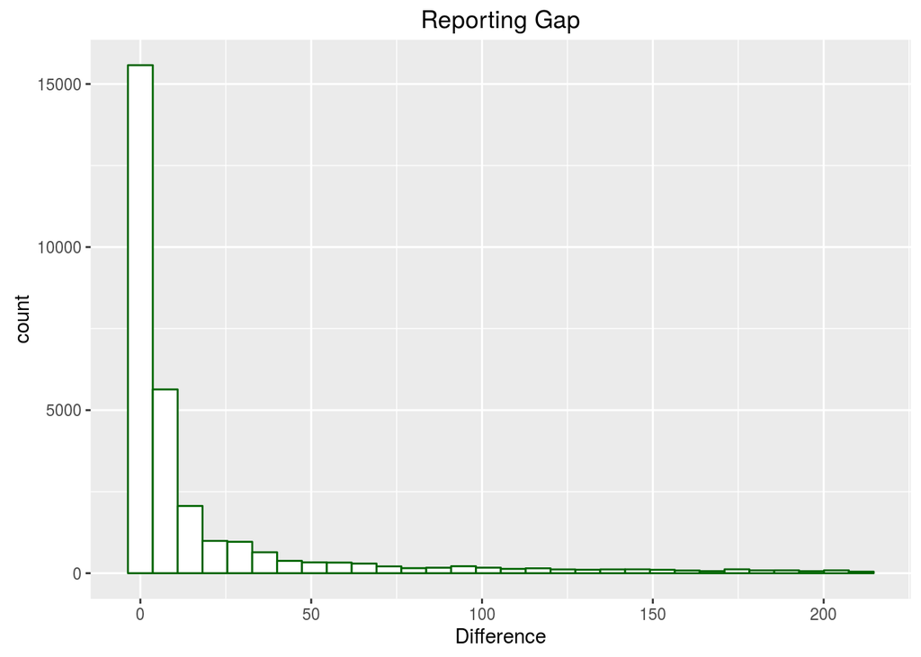

```r
ufo2 = filter(ufo, Difference > 0 & Difference < 213)
ggplot() +
  geom_histogram(data = ufo2, aes(x = Difference),
                colour = "darkgreen", fill="white") +
  ggtitle("Reporting Gap")
```

**Ваша очередь:**

- Постройте график, показывающий распределение наблюдений НЛО (`Sighted`) по годам (чтобы оставить от даты только год, нужно использовать функцию `year()`). Ограничьте график периодом с 1998 по 2008.
- Постройте график, показывающий распределение наблюдений НЛО (`Sighted`) по дням недели (функция `wday()`)
- Оставьте только данные, соответствующие наблюдениям после 2004 года. Дальше работаем только с этой подвыборкой.
- Оставьте только те данные, в которых указана форма НЛО (`Shape`). Условие на “непропущенные данные” можно задать как `!is.na(Shape)`
- НЛО какой формы наблюдали чаще после 2004 года? Посчитайте и покажите на графике
- В какой день недели чаще наблюдали НЛО в форме сферы (sphere)?
- НЛО какой формы имеет наибольшую среднюю разницу между временем наблюдения и сообщения (`Difference`)? Для ответа на этот вопрос используйте функции группировки (`group_by()`) и (`summarize()`) агрегации из пакета dplyr.